# Lesson_5_problem_set

```r
library(dplyr)
library(ggplot2)
library(tidyr)
library(GGally)

data(diamonds)
```

```r
names(diamonds)
```

```
##  [1] "carat"   "cut"     "color"   "clarity" "depth"   "table"   "price"
##  [8] "x"       "y"       "z"
```

## Problem 1

Create a histogram of diamond prices. Facet the histogram by diamond color and use cut to color the histogram bars.

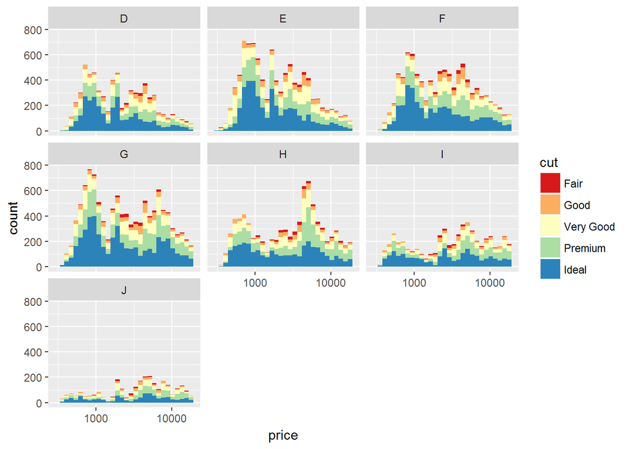

```r
ggplot(aes(x = price), data = diamonds) +
    geom_histogram(aes(fill = cut)) +
    facet_wrap(~color) +
    scale_fill_brewer(palette = 'Spectral') +
    scale_x_log10()
```

## Problem 2

Create a scatterplot of diamond price vs. table and color the points by the cut of the diamond.

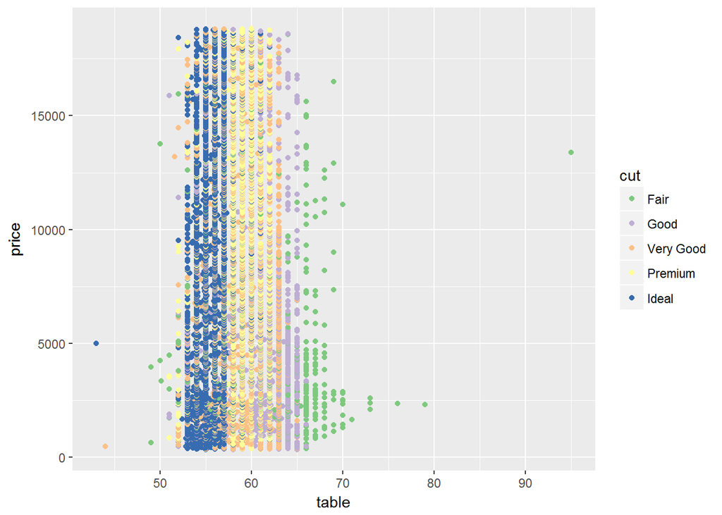

```r
ggplot(aes(x = table, y = price, color = cut), data = diamonds) +
    geom_point() +
    scale_color_brewer(type = 'qual')
```

## problem 3

```r
diamonds$volume = (diamonds$x * diamonds$y * diamonds$z)
head(diamonds)
```

```
## # A tibble: 6 × 11
##   carat       cut color clarity depth table price     x     y     z
##   <dbl>     <ord> <ord>   <ord> <dbl> <dbl> <int> <dbl> <dbl> <dbl>
## 1  0.23     Ideal     E     SI2  61.5    55   326  3.95  3.98  2.43
## 2  0.21   Premium     E     SI1  59.8    61   326  3.89  3.84  2.31
## 3  0.23      Good     E     VS1  56.9    65   327  4.05  4.07  2.31
## 4  0.29   Premium     I     VS2  62.4    58   334  4.20  4.23  2.63
## 5  0.31      Good     J     SI2  63.3    58   335  4.34  4.35  2.75
## 6  0.24 Very Good     J    VVS2  62.8    57   336  3.94  3.96  2.48
## # ... with 1 more variables: volume <dbl>
```

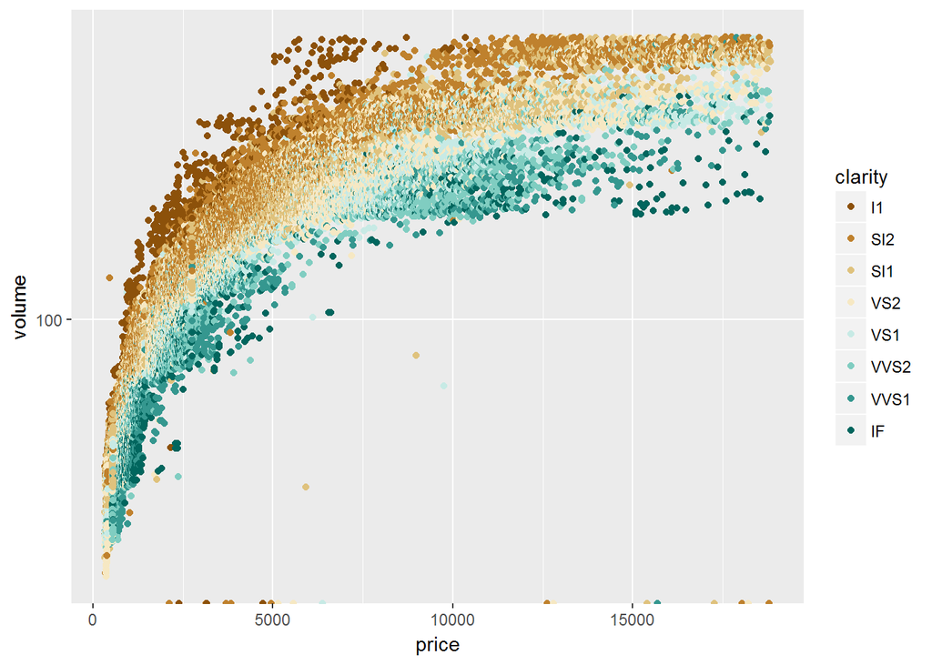

```r
ggplot(aes(x = price, y = volume,), data = diamonds[diamonds$volume < quantile(diamonds$volume, 0.99),]) +
    geom_point(aes(color = clarity)) +
    scale_y_log10() +
    scale_color_brewer(type = 'div')
```

## Problem 4

Your task is to create a new variable called ‘prop_initiated’ in the Pseudo-Facebook data set. The variable should contain the proportion of friendships that the user initiated.

```r
pf <- read.delim('pseudo_facebook.tsv')

#recreate year_joined.bucket
pf$year_joined <- floor(2014 - pf$tenure/365)
pf$year_joined.bucket <- cut(pf$year_joined,
                             c(2004, 2009, 2011, 2012, 2014))

pf$prop_initiated <- with(pf, friendships_initiated / friend_count)
```

## Problem 5

Create a line graph of the median proportion of friendships initiated (‘prop_initiated’) vs. tenure and color the line segment by year_joined.bucket.

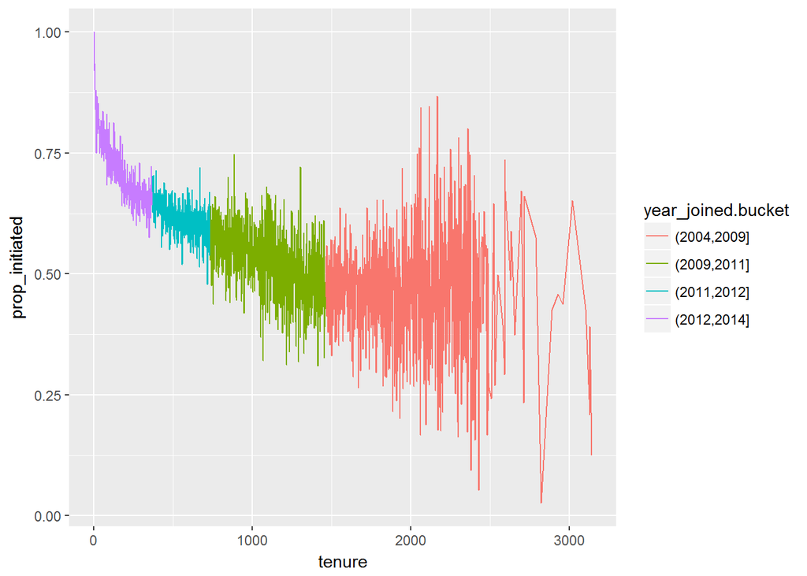

```r
ggplot(aes(x = tenure, y = prop_initiated), data = pf) +
    geom_line(aes(color = year_joined.bucket), stat = 'summary', fun.y = median)
```

## Problem 6

Smooth the last plot you created of of prop_initiated vs tenure colored by year_joined.bucket. You can bin together ranges of tenure or add a smoother to the plot.

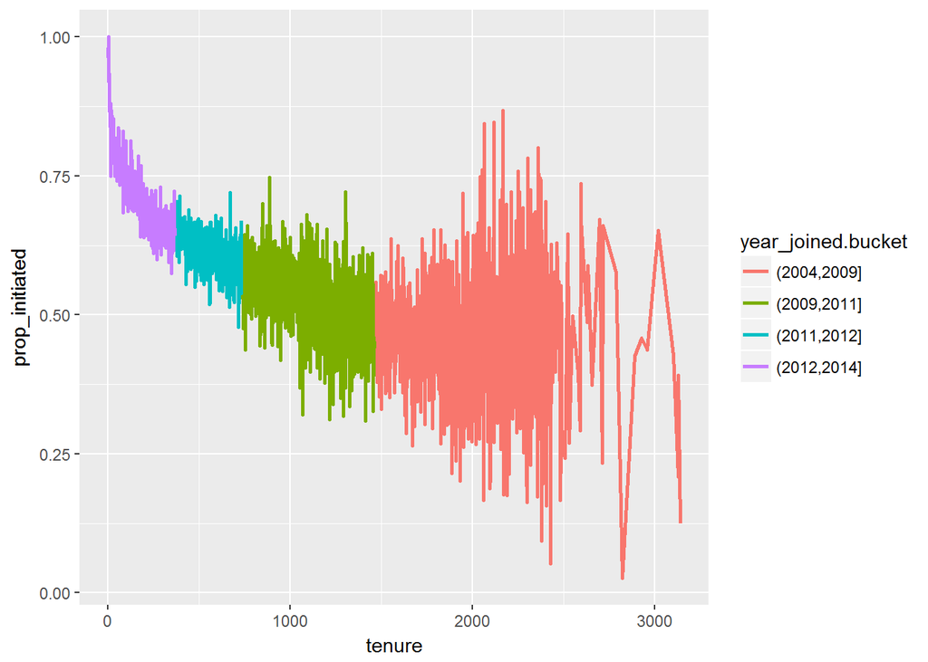

```r
ggplot(aes(x = tenure, y = prop_initiated), data = subset(pf, !is.na(pf$prop_initiated))) +
    geom_smooth(aes(color = year_joined.bucket), stat = 'summary', fun.y = median)
```

## Problem 7

Create a scatter plot of the price/carat ratio of diamonds. The variable x should be assigned to cut. The points should be colored by diamond color, and the plot should be faceted by clarity.

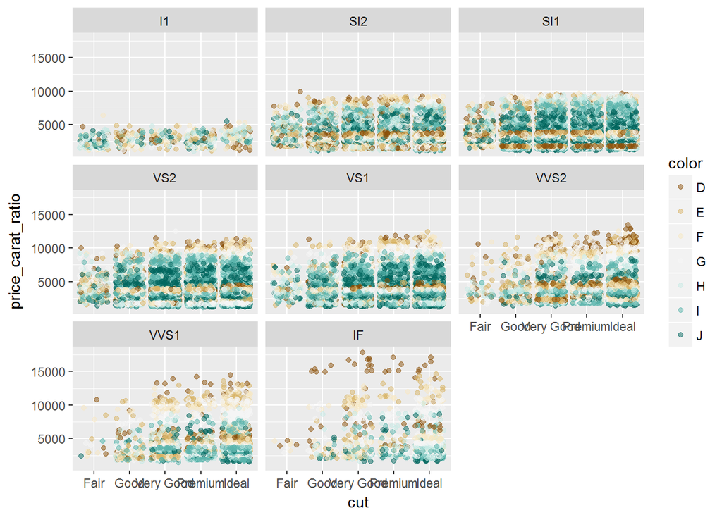

```r
diamonds$price_carat_ratio <- with(diamonds, price/carat)


ggplot(aes(x = cut, y = price_carat_ratio), data = diamonds) +
    geom_jitter(aes(color = color), alpha = 0.5) +
    facet_wrap(~clarity) +
    scale_color_brewer(type = 'div')
```

The Gapminder website contains over 500 data sets with information about the world’s population. Your task is to continue the investigation you did at the end of Problem Set 4 or you can start fresh and choose a different data set from Gapminder. If you’re feeling adventurous or want to try some data munging see if you can find a data set or scrape one from the web.

In your investigation, examine 3 or more variables and create 2-5 plots that make use of the techniques from Lesson 5.

You can find a link to the Gapminder website in the Instructor Notes.

Once you’ve completed your investigation, create a post in the discussions that includes: 1. the variable(s) you investigated, your observations, and any summary statistics 2. snippets of code that created the plots 3. links to the images of your plots

Copy and paste all of the code that you used for your investigation, and submit it when you are ready.